# Project_1.0.2

> What did the Montgomery College student body look like in the fall of 2015? How did Montgomery College students compare to Montgomery County in the fall of 2015?

```r
library(dplyr) #Load library for analysis
```

Data for the college is available at https://data.montgomerycountymd.gov/Education/Montgomery-College-Enrollment-Data/wmr2-6hn6/data Demographic data is available at https://datausa.io/profile/geo/montgomery-county-md/#economy For this example, downloaded the data in csv format and loaded it to my machine. If you use this, be sure to export the data to your machine and updated the noted directory. #

```r
mcData <- read.csv(file="https://raw.githubusercontent.com/TimSrenaski/DATA101/master/Project_1/Montgomery_College_Enrollment_Data.csv", header=TRUE, sep=",") #<-----Update with personal directory
countyRaceData <- read.csv(file="https://github.com/TimSrenaski/DATA101/blob/master/Project_1/datausa_race.csv", header=TRUE, sep=",") #<-----Update with personal directory
countyOccData <- read.csv(file="C:/Users/timsr/OneDrive/Documents/R/DATA_101/datausa_occupations.csv", header=TRUE, sep=",") #<-----Update with personal directory
```

> What are the column names in the college data?

```r
colnames(mcData)
```

```
##  [1] "Fall.Term"                "Student.Type"
##  [3] "Student.Status"           "Gender"
##  [5] "Ethnicity"                "Race"
##  [7] "Attending.Germantown"     "Attending.Rockville"
##  [9] "Attending.Takoma.Park.SS" "Attend.Day.or.Evening"
## [11] "MC.Program.Description"   "Age.Group"
## [13] "HS.Category"              "MCPS.High.School"
## [15] "City.in.MD"               "State"
## [17] "ZIP"                      "County.in.MD"
```

> Is the data clean?

```r
unique(mcData$Fall.Term)
```

```
## [1] 2015
```

```r
unique(mcData$Student.Type)
```

```
## [1] Continuing           New                  Transfer no degree
## [4] HS Student           Transfer with degree Transfer
## [7] New/No HS
## 7 Levels: Continuing HS Student New New/No HS ... Transfer with degree
```

```r
unique(mcData$Student.Status)
```

```
## [1] Full-Time Part-Time
## Levels: Full-Time Part-Time
```

```r
unique(mcData$Gender)
```

```
## [1] Female  Male    Unknown
## Levels: Female Male Unknown
```

```r
unique(mcData$Ethnicity)
```

```
## [1] Not Hispanic Hispanic     Unknown
## Levels: Hispanic Not Hispanic Unknown
```

```r
unique(mcData$Race)
```

```
## [1] White            Black            Asian            Hispanic
## [5] Pacific Islander Multi-Race       Native American  Unknown
## 8 Levels: Asian Black Hispanic Multi-Race ... White
```

```r
unique(mcData$Attending.Germantown)
```

```
## [1] Yes No
## Levels: No Yes
```

```r
unique(mcData$Attending.Rockville)
```

```
## [1] Yes No
## Levels: No Yes
```

```r
unique(mcData$Attending.Takoma.Park.SS)
```

```
## [1] No  Yes
## Levels: No Yes
```

```r
unique(mcData$Attend.Day.or.Evening)
```

```
## [1] Day Only                 Evening Only
## [3] Day & Evening            No Specific Time[online]
## 4 Levels: Day & Evening Day Only ... No Specific Time[online]
```

```r
unique(mcData$MC.Program.Description)
```

```
##  [1] Health Sciences (Pre-Clinical Studies)
##  [2] Building Trades Technology (AA & AAS)
##  [3] Computer Gaming & Simulation (AA - All Tracks)
##  [4] Graphic Design (AA, AAS, & AFA - All Tracks)
##  [5] General Studies (AA - All Tracks)
##  [6] Engineering Science (AA & AS - All Tracks)
##  [7] Education / Teacher Education (AA & AAT)
##  [8] Business / International Business (AA)
##  [9] Computer Science & Technologies (AA - All Tracks)
## [10] Criminal Justice (AA & AAS)
## [11] Diagnostic Medical Sonography (AA & AAS)
## [12] Arts & Sciences Transfer (AA - All Tracks)
## [13] Credit (Undeclared / Undecided)
## [14] Science (AS - All Tracks)
## [15] Accounting (AA & AAS)
```

[output cut: 82 more lines]

```r
unique(mcData$Age.Group)
```

```
## [1] 25 - 29       21 - 24       20 or Younger 30 or Older   Unknown
## Levels: 20 or Younger 21 - 24 25 - 29 30 or Older Unknown
```

```r
unique(mcData$HS.Category)
```

```
## [1] Foreign Country   MCPS              Mont.County Other Other State
## [5] Other Maryland    GED               Home-Schooled
## 7 Levels: Foreign Country GED Home-Schooled MCPS ... Other State
```

```r
unique(mcData$MCPS.High.School)
```

```
##  [1]                                Sherwood High School
##  [3] Quince Orchard Sr High School  Thomas Sprigg Wootton High Sch
##  [5] Montgomery Blair High School   Clarksburg High School
##  [7] Bethesda Chevy Chase High Schl Winston Churchill High School
##  [9] Rockville High School          Northwood High School
## [11] Colonel Zadok Magruder HS      Northwest HS - Germantown
## [13] Walter Johnson High School     Richard Montgomery High School
## [15] Seneca Valley High School      Wheaton High School
## [17] Gaithersburg High School       Damascus High School
## [19] Springbrook Sr High School     Paint Branch High School
## [21] Albert Einstein HS & MC Art Cn Watkins Mill High School
## [23] James Hubert Blake High School Walt Whitman High School
## [25] John F. Kennedy High School    Poolesville Jr-Sr High School
## 26 Levels:  ... Winston Churchill High School
```

```r
unique(mcData$City.in.MD)
```

```
##   [1] Bethesda             Olney                Gaithersburg
##   [4] North Potomac        Silver Spring        Germantown
##   [7] Rockville            Darnestown           Prince Frederick
##  [10] Derwood              Potomac              Washington
##  [13] Montgomery Village   Columbia             Takoma Park
##  [16] Kensington           Poolesville          Clarksburg
##  [19] Hyattsville          Bowie                Clinton
##  [22] Harpers Ferry        Chevy Chase          Spencerville
##  [25] Larbo                Burtonsville         Beltsville
##  [28] North Bethesda       Boyds                Waldorf
##  [31] Cheverly             Brookeville          District Heights
##  [34] Damascus             Annapolis            Laytonsville
##  [37] Sandy Spring         Laurel
##  [40] New Carrollton       Dickerson            University Park
##  [43] Temple Hills         Riverdale            Greenbelt
```

[output cut: 67 more lines]

```r
unique(mcData$State)
```

```
##  [1] MD DC MO WV VA GA CA MA TX    NC MI CT SC PA NY PR OH FL TN NJ DE OK
## 23 Levels:  CA CT DC DE FL GA MA MD MI MO NC NJ NY OH OK PA PR SC ... WV
```

```r
unique(mcData$ZIP)
```

```
##   [1] 20816 20832 20877 20878 20906 20876 20903 20901 20851 20904 20910
##  [12] 20850 20902 20678 20855 20874 20852 20854 20020 20814 20879 20886
##  [23] 20915 65203 20853 20912 20882 20817 20895 20837 20871 20784 20783
##  [34] 20720 20721 20735 25425 20815 20868 20905 20015 20774 20008 20032
##  [45] 20019 20866 20705 20782 20841 20603 20785 20009 20001 20833 20747
##  [56] 20002 20872 21404 20018 20860 20707    NA 20842 20748 20737 20770
##  [67] 20706 20722 21045 21117 21208 21713 20012 20781 20862 20011 20861
##  [78] 20744 21075 20889 20010 20017 20708 20740 20772 22304 20746 30080
##  [89] 20024 21701 95492 20743 20712 20896 20037 20716 20016 20121 21769
## [100] 20695 94547 20003 21771 21042 21702 20880 20005  2050 21244 21044
## [111] 21742 21225 20769 21704 20198 21403 20148 21703 20898 22209 75038
## [122] 21770 22033 22102 21740 20745 20818 20914 20839 76015 21774 20007
## [133] 22315 21234 27510 20724 22003 22204 63301 20907 20039 22041 20601
## [144] 20754 21856 21754 20165 21784 20875 20838 20812 21797 28328 20741
## [155] 20715 21218 20848 21795 20777 20710 22182 30342 49506 21239 21040
## [166] 20723 21217 22201 21113  6880 29164 21773 25403 21030 20918 22181
## [177] 22152 21136 22153 21223 20830 21286  6830 75230 21144 30062 20004
## [188] 20602 20845 20847 22191 21061 17325 22202 19129 10028 21157 21043
## [199] 21779 21723 20849 94597 22192 21076 31405 20147 21060 22307 20835
## [210] 29063 20040 20111 20124 91405 27253   926 44087 15217 20105 21738
## [221] 21236 21794 20916 21108 94116 43920 22203 30076 22193 20152 21204
## [232] 21229 21601 22015 21710 21409 21224 21201 17102 33496 37206 21212
## [243] 21620 20787 20640 49504 21046 22314 29406 21211 21122 11422  7102
## [254] 21009 22046 18938 20607 10463 21811 22801 20658 20036 21401 19966
## [265] 21722 20120 21638 20732 19904 73717 49329 21716 21801 20180 21758
## [276] 23834 21798 28311 11566 23901 20909 22206 20734 21206 21220 43235
## [287] 20171 22601 20170 20637 20794 22205 21793 21158 33614 20759 22309
## [298] 20166 20978 17222 27517 13215 13031 93003 25443 20810 19933 21093
## [309] 16823 20883 17268 21215 21750 21228 22027 20619 15235 12203 20613
## [320] 21104
```

```r
unique(mcData$County.in.MD)
```

```
##  [1] Montgomery      Calvert         Other           Prince George's
##  [5] Washington      Charles         Anne Arundel    Howard
##  [9] Baltimore       Frederick       Wicomico        Carroll
## [13] Baltimore City  Harford         Talbot          Kent
## [17] Worcester       Queen Anne's    St. Mary's
## 19 Levels: Anne Arundel Baltimore Baltimore City Calvert ... Worcester
```

[figure not shown]

What have we noticed on general inspection?

- It looks like there is only one value present in the Fall.Term column. This will make it an excellent quantitative count to establish a full record count.
- The race categories line up perfectly with the race categories in the DataUSA file.

> Problems with the data:
- The Ethnicity column is unlikely to be useful, the Race column gives much greater detail.
- The No/Yes responses will need to be converted to 0/1 for counting purposes in the Attending columns.
- The Program Descriptions will need to be grouped to make any meaningful comparision to the DataUSA file.
- The Age.Group column is useless for analysis because of the grouping. I should try to use it to make a bar chart for visuals.
- Blank high schools in the MCPS.High.School column likley refrence HS outside of the area.
- There are misspellings in city name causing under representation for some communites.
- There are also blank entries in the City in MD column.
- There is a blank entry in the State column.
- There are NAs as well as a few zip codes that are not five digits # #

```r
studentCount <- nrow(mcData) # Determine how many students are enrolled in the fall of 2015
studentCount
```

```
## [1] 25320
```

```r
x <- mcData %>%
  group_by(Student.Status) %>%
  summarize(Count = n_distinct(MC.Program.Description))

x <- arrange(x, desc(Count))
x
```

| Student.Status | Count |
| --- | --- |
| Part-Time | 94 |
| Full-Time | 78 |

```r
unique(countyOccData$acs_occ_name) # Determine the occupation categories we should filter the MC.Program.Descriptions into
```

```
##  [1] Management
##  [2] Business & Financial Operations
##  [3] Computer & Mathematical
##  [4] Architecture & Engineering
##  [5] Life, Physical, & Social Science
##  [6] Community & Social Service
##  [7] Legal
##  [8] Education, Training, & Library
##  [9] Arts & Recreation
## [10] Health Practitioners
## [11] Health Technicians
## [12] Healthcare Support
## [13] Law Enforcement Supervisors
## [14] Fire Fighting Supervisors
## [15] Food & Serving
## [16] Cleaning & Maintenance
## [17] Personal Care & Service
## [18] Sales
## [19] Administrative
## [20] Farming, Fishing, & Forestry
## [21] Construction & Extraction
## [22] Installation, Maintenance, & Repair
## [23] Production
## [24] Transportation
## [25] Material Moving
## 25 Levels: Administrative Architecture & Engineering ... Transportation
```

```r
# Group all declared programs to Occupations listed in the Occupational data

Managment <-(c("Management (CT)", "Hospitality Management (AA & AAS)",
               "Health Information Management (AA & AAS)", "Hospitality Management (CT)",
               "Diagnostic Medical Sonography (CT)", "Hospitality Management (LR)",
               "Management (AA & AAS - All Tracks)", "Management (LR)",
               "Printing Management (AA & AAS)", "Medical Coder/Abstractr/Biller (CT)",
               "Printing Management (CT)"))
Business.Financial.Operations <-(c("Business / International Business (AA)",
                                   "Accounting (AA & AAS)", "Accounting (CT)"))
Computer.Mathematical <-(c("Computer Gaming & Simulation (AA - All Tracks)",
                           "Graphic Design (AA, AAS, & AFA, - All Tracks)",
                           "Computer Science & Technologies (AA = All Tracks)",
                           "Cybersecurity (AAS)", "Computer Applications (CT)",
                           "Microcomputer Technician (AA & AAS)",
                           "Digital Media & Web Technology (AAS)",
                           "Computer Applications (AA & AAS)",
                           "Digital Media & Web Technology (CT)",
                           "Microcomputer Technician (CT)", "Cybersecurity (CT)",
                           "Information Systems Secirity",
                           "Computer Graphics / Graphic Design (CT)",
                           "Computer Graphics / Graphic Design (AAS)",
                           "Network & Wireless Technologies (CT)",
                           "Network Engineer/Administration (CT)"))
Architecture.Engineering <-(c("Engineering Science (AA - All Tracks)",
                              "Architectural & Construction Tech (AA & AAS)",
                              "Interior Design (CT)",
                              "Interior Design - PreProfessional (AAS)",
                              "Architect. & Construct. Tech - Sustainability (LR)",
                              "Eng Technologies (AA & AAS - Discontinued)"))
Life.Physical.Social.Science <-(c("Science (AS - All Tracks)", "Biotechnology (AA & AAS)",
                                  "Applied Geography (AA & AAS)", "Biotechnology (CT)",
                                  "Technical Writing (CT)",
                                  "Cartography & Geographic Ed / Info Sys (CT)",
                                  "Ethnic Social Studies (LR)",
                                  "Women's Studies (CT)", "Ethnic Studies (CT)"))
Community.Social.Service <-(c("American Sign Language (AA & AAS)"))
Legal <-(c("Criminal Justice (AA & AAS)", "Paralegal Studies (AA & AAS)","Paralegal Studies (CT)",
           "Paralegal Studies - Legal Analysis (LR)"))
Education.Training <-(c("Education / Teaching Education (AA & AAT)",
                        "Early Childhood Education (AA & AAS)", " Early Childhood Education (CT)",
                        "Early Childhood Education (LR)"))
Arts.Recreation <-(c("School of Art & Design - Applicants", "Photography (AA & AAS)",
                     "Commun & Broadcasting Tech (CT)",
                     "Commun & Broadcasting Tech (AA & AAS - All Tracks)",
                     "Studio Art (AFA) - School of Art & Design", "Specialized Art Transfer (CT)",
                     "Photography (CT)", "Music Transfer (CT)",
                     "Graphic Design (AFA) - School of Art & Design", "Studio Art (AFA)",
                     "Recreation Leadership (AA)"))
Health <-(c("Health Sciences (Pre-Clinical Studies)", "Diagnostic Medical Sonography (AA & AAS)",
            "Nursing (AA & AAS)", "Mental Health Associate (AA & AAS)",
            "Polysomnography Technology (CT)", "Radiologic (X-Ray) Technology (AA & AAS)",
            "Physical Therapist Assistant (AAS)", "Surgical Technologist (AAS)",
            "Exercise Sci - Personal Trainer (LR)",
            "Exercise Sci - Personal Trainer (CT)"))
Law.Enforcement  <-(c())
Fire.Fighting  <-(c("Fire Sci./Preven., Emerg. Prepare. (AA, AS & AAS)",
                    "Fire Sci./Preven., Emergency Prepare. (CT)", "Fire Science (LR)"))
Food.Service  <-(c())
Cleaning.Maintenance  <-(c())
Personal.Care.Service  <-(c())
Sales  <-(c())
Administrative  <-(c("Communication Studies (AA)", "American Sign Language (CT)",
                     "Administrative Support Tech (CT)"))
Farming.Fishing.Forestry  <-(c())
Construction.Extraction  <-(c("Building Trades Technology (AA & AAS)",
                              "Building Trades Technology (CT)", "Management of Construction (CT)",
                              "Landscape Technology (AA & AAS)", "Building Trades Technology (LR)",
                              "Landscape Technology (CT)"))
Installation.Maintenance.Repair  <-(c("Automotive Technology (AA & AAS)",
                                      "Automotive Technology (CT)",
                                      "Electromechanical Sys Eng Tech (AA & AAS - Discnt)"))
Transportation  <-(c())
Materal.Moving  <-(c())
Other <-(c("General Studies (AA - All Tracks)","Arts & Sciences Transfer (AA - All Tracks)",
           "Credit (Undeclared / Undecided)", "WIA (CE) Programs", "Arts & Sciences Transfer (CT)"))
```

> Student body details (Macro perspective)

```r
Student.Type <- select(mcData, Student.Type)
studentTypeTable <- as.data.frame(table(Student.Type))

studentType <- arrange(studentTypeTable, desc(Freq)) %>%
  mutate(Share.Enrollment = round((Freq / studentCount),digits = 3))
studentType
```

| Student.Type | Freq | Share.Enrollment |
| --- | --- | --- |
| Continuing | 18513 | 0.731 |
| New | 4767 | 0.188 |
| Transfer no degree | 1132 | 0.045 |
| HS Student | 485 | 0.019 |
| Transfer with degree | 343 | 0.014 |
| Transfer | 51 | 0.002 |
| New/No HS | 29 | 0.001 |

```r
Student.Gender <- select(mcData, Gender)
studentGenderTable <- as.data.frame(table(Student.Gender))

studentGender <- arrange(studentGenderTable, desc(Freq)) %>%
  mutate(Share.Enrollment = round((Freq / studentCount),digits = 3))
studentGender
```

| Student.Gender | Freq | Share.Enrollment |
| --- | --- | --- |
| Female | 13350 | 0.527 |
| Male | 11963 | 0.472 |
| Unknown | 7 | 0.000 |

```r
Student.Race <- select(mcData, Race)
studentRaceTable <- as.data.frame(table(Student.Race))

studentRace <- arrange(studentRaceTable, desc(Freq)) %>%
  mutate(Share.Enrollment = round((Freq / studentCount),digits = 3))
studentRace
```

| Student.Race | Freq | Share.Enrollment |
| --- | --- | --- |
| White | 9831 | 0.388 |
| Black | 8217 | 0.325 |
| Asian | 3538 | 0.140 |
| Hispanic | 2028 | 0.080 |
| Multi-Race | 860 | 0.034 |
| Native American | 501 | 0.020 |
| Pacific Islander | 293 | 0.012 |
| Unknown | 52 | 0.002 |

```r
Student.Age.Group <- select(mcData, Age.Group)
studentAgeGroupTable <- as.data.frame(table(Student.Age.Group))

studentAgeGroup <- arrange(studentAgeGroupTable, desc(Freq)) %>%
  mutate(Share.Enrollment = round((Freq / studentCount),digits = 3))
studentAgeGroup
```

| Student.Age.Group | Freq | Share.Enrollment |
| --- | --- | --- |
| 20 or Younger | 10533 | 0.416 |
| 21 - 24 | 6349 | 0.251 |
| 30 or Older | 5116 | 0.202 |
| 25 - 29 | 3320 | 0.131 |
| Unknown | 2 | 0.000 |

```r
Student.City <- select(mcData, City.in.MD)
studentCityTable <- as.data.frame(table(Student.City))

studentCity <- arrange(studentCityTable, desc(Freq)) %>%
  mutate(Share.Enrollment = round((Freq / studentCount),digits = 3))
studentCity
```

| Student.City | Freq | Share.Enrollment |
| --- | --- | --- |
| Silver Spring | 7464 | 0.295 |
| Gaithersburg | 3220 | 0.127 |
| Rockville | 2925 | 0.116 |
| Germantown | 2675 | 0.106 |
| Montgomery Village | 901 | 0.036 |
| Bethesda | 812 | 0.032 |
| Washington | 726 | 0.029 |
| Takoma Park | 586 | 0.023 |
| Olney | 560 | 0.022 |
| Potomac | 550 | 0.022 |

[output cut: 232 more lines]

```r
Student.Program <- select(mcData, MC.Program.Description)
studentProgramTable <- as.data.frame(table(Student.Program))

studentProgram <- arrange(studentProgramTable, desc(Freq)) %>%
  mutate(Share.Enrollment = round((Freq / studentCount),digits = 3))
studentProgram
```

| Student.Program | Freq | Share.Enrollment |
| --- | --- | --- |
| General Studies (AA - All Tracks) | 7449 | 0.294 |
| Health Sciences (Pre-Clinical Studies) | 2969 | 0.117 |
| Business / International Business (AA) | 2289 | 0.090 |
| Engineering Science (AA & AS - All Tracks) | 1482 | 0.059 |
| Science (AS - All Tracks) | 1432 | 0.057 |
| Arts & Sciences Transfer (AA - All Tracks) | 1134 | 0.045 |
| Credit (Undeclared / Undecided) | 1127 | 0.045 |
| Computer Science & Technologies (AA - All Tracks) | 866 | 0.034 |
| Education / Teacher Education (AA & AAT) | 845 | 0.033 |
| Criminal Justice (AA & AAS) | 638 | 0.025 |

[output cut: 86 more lines]

> Student body details

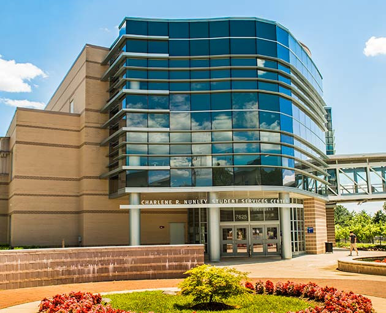

Takoma Park/Silver Spring

```r
TP.SS <- filter(mcData, Attending.Takoma.Park.SS =="Yes", Attending.Rockville == "No", Attending.Germantown == "No")
TP.SS.Student.Type <- select(TP.SS, Student.Type)
TP.SS.studentTypeTable <- as.data.frame(table(TP.SS.Student.Type))

TP.SS.studentType <- arrange(TP.SS.studentTypeTable, desc(Freq)) %>%
  mutate(Share.Enrollment = round((Freq / sum(Freq)),digits = 3))
TP.SS.studentType
```

| TP.SS.Student.Type | Freq | Share.Enrollment |
| --- | --- | --- |
| Continuing | 3442 | 0.702 |
| New | 1008 | 0.206 |
| Transfer no degree | 282 | 0.058 |
| Transfer with degree | 99 | 0.020 |
| HS Student | 56 | 0.011 |
| Transfer | 10 | 0.002 |
| New/No HS | 6 | 0.001 |

```r
TP.SS <- filter(mcData, Attending.Takoma.Park.SS =="Yes", Attending.Rockville == "No", Attending.Germantown == "No")
TP.SS.Student.Gender <- select(TP.SS, Gender)
TP.SS.studentGenderTable <- as.data.frame(table(TP.SS.Student.Gender))

TP.SS.studentGender <- arrange(TP.SS.studentGenderTable, desc(Freq)) %>%
  mutate(Share.Enrollment = round((Freq / sum(Freq)),digits = 3))
TP.SS.studentGender
```

| TP.SS.Student.Gender | Freq | Share.Enrollment |
| --- | --- | --- |
| Female | 2908 | 0.593 |
| Male | 1994 | 0.407 |
| Unknown | 1 | 0.000 |

```r
TP.SS <- filter(mcData, Attending.Takoma.Park.SS =="Yes", Attending.Rockville == "No", Attending.Germantown == "No")
TP.SS.Student.Race <- select(TP.SS, Race)
TP.SS.studentRaceTable <- as.data.frame(table(TP.SS.Student.Race))

TP.SS.studentRace <- arrange(TP.SS.studentRaceTable, desc(Freq)) %>%
  mutate(Share.Enrollment = round((Freq / sum(Freq)),digits = 3))
TP.SS.studentRace
```

| TP.SS.Student.Race | Freq | Share.Enrollment |
| --- | --- | --- |
| Black | 2624 | 0.535 |
| White | 1195 | 0.244 |
| Asian | 421 | 0.086 |
| Hispanic | 376 | 0.077 |
| Multi-Race | 132 | 0.027 |
| Native American | 99 | 0.020 |
| Pacific Islander | 46 | 0.009 |
| Unknown | 10 | 0.002 |

```r
TP.SS <- filter(mcData, Attending.Takoma.Park.SS =="Yes", Attending.Rockville == "No", Attending.Germantown == "No")
TP.SS.Student.Age.Group <- select(TP.SS, Age.Group)
TP.SS.studentAgeGroupTable <- as.data.frame(table(TP.SS.Student.Age.Group))

TP.SS.studentAgeGroup <- arrange(TP.SS.studentAgeGroupTable, desc(Freq)) %>%
  mutate(Share.Enrollment = round((Freq / sum(Freq)),digits = 3))
TP.SS.studentAgeGroup
```

| TP.SS.Student.Age.Group | Freq | Share.Enrollment |
| --- | --- | --- |
| 20 or Younger | 1713 | 0.349 |
| 30 or Older | 1257 | 0.256 |
| 21 - 24 | 1186 | 0.242 |
| 25 - 29 | 747 | 0.152 |
| Unknown | 0 | 0.000 |

```r
TP.SS <- filter(mcData, Attending.Takoma.Park.SS =="Yes", Attending.Rockville == "No", Attending.Germantown == "No")
TP.SS.Student.City <- select(TP.SS, City.in.MD)
TP.SS.studentCityTable <- as.data.frame(table(TP.SS.Student.City))

TP.SS.studentCity <- arrange(TP.SS.studentCityTable, desc(Freq)) %>%
  mutate(Share.Enrollment = round((Freq / sum(Freq)),digits = 3))
TP.SS.studentCity
```

| TP.SS.Student.City | Freq | Share.Enrollment |
| --- | --- | --- |
| Silver Spring | 2450 | 0.500 |
| Washington | 431 | 0.088 |
| Takoma Park | 376 | 0.077 |
| Hyattsville | 190 | 0.039 |
| Rockville | 137 | 0.028 |
| Gaithersburg | 124 | 0.025 |
| Germantown | 116 | 0.024 |
| Burtonsville | 115 | 0.023 |
| Beltsville | 64 | 0.013 |
| Bethesda | 63 | 0.013 |

[output cut: 232 more lines]

```r
TP.SS <- filter(mcData, Attending.Takoma.Park.SS =="Yes", Attending.Rockville == "No", Attending.Germantown == "No")
TP.SS.Student.Program <- select(TP.SS, MC.Program.Description)
TP.SS.studentProgramTable <- as.data.frame(table(TP.SS.Student.Program))

TP.SS.studentProgram <- arrange(TP.SS.studentProgramTable, desc(Freq)) %>%
  mutate(Share.Enrollment = round((Freq / sum(Freq)),digits = 3))
TP.SS.studentProgram
```

| TP.SS.Student.Program | Freq | Share.Enrollment |
| --- | --- | --- |
| General Studies (AA - All Tracks) | 1120 | 0.228 |
| Health Sciences (Pre-Clinical Studies) | 934 | 0.190 |
| Business / International Business (AA) | 372 | 0.076 |
| Nursing (AA & AAS) | 342 | 0.070 |
| Science (AS - All Tracks) | 310 | 0.063 |
| Credit (Undeclared / Undecided) | 216 | 0.044 |
| Engineering Science (AA & AS - All Tracks) | 203 | 0.041 |
| Arts & Sciences Transfer (AA - All Tracks) | 195 | 0.040 |
| Computer Science & Technologies (AA - All Tracks) | 127 | 0.026 |
| Criminal Justice (AA & AAS) | 117 | 0.024 |

[output cut: 86 more lines]

> Student body details

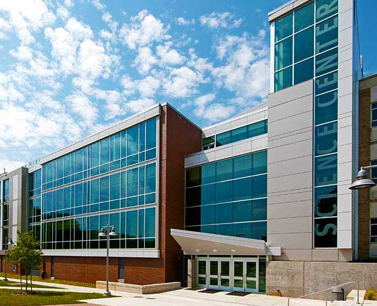

Rockville

```r
RV <- filter(mcData, Attending.Takoma.Park.SS =="No", Attending.Rockville == "Yes", Attending.Germantown == "No")
RV.Student.Type <- select(RV, Student.Type)
RV.studentTypeTable <- as.data.frame(table(RV.Student.Type))

RV.studentType <- arrange(RV.studentTypeTable, desc(Freq)) %>%
  mutate(Share.Enrollment = round((Freq / sum(Freq)),digits = 3))
RV.studentType
```

| RV.Student.Type | Freq | Share.Enrollment |
| --- | --- | --- |
| Continuing | 8010 | 0.726 |
| New | 2216 | 0.201 |
| Transfer no degree | 402 | 0.036 |
| HS Student | 212 | 0.019 |
| Transfer with degree | 156 | 0.014 |
| Transfer | 24 | 0.002 |
| New/No HS | 17 | 0.002 |

```r
RV <- filter(mcData, Attending.Takoma.Park.SS =="No", Attending.Rockville == "Yes", Attending.Germantown == "No")
RV.Student.Gender <- select(RV, Gender)
RV.studentGenderTable <- as.data.frame(table(RV.Student.Gender))

RV.studentGender <- arrange(RV.studentGenderTable, desc(Freq)) %>%
  mutate(Share.Enrollment = round((Freq / sum(Freq)),digits = 3))
RV.studentGender
```

| RV.Student.Gender | Freq | Share.Enrollment |
| --- | --- | --- |
| Male | 5590 | 0.506 |
| Female | 5443 | 0.493 |
| Unknown | 4 | 0.000 |

```r
RV <- filter(mcData, Attending.Takoma.Park.SS =="No", Attending.Rockville == "Yes", Attending.Germantown == "No")
RV.Student.Race <- select(RV, Race)
RV.studentRaceTable <- as.data.frame(table(RV.Student.Race))

RV.studentRace <- arrange(RV.studentRaceTable, desc(Freq)) %>%
  mutate(Share.Enrollment = round((Freq / sum(Freq)),digits = 3))
RV.studentRace
```

| RV.Student.Race | Freq | Share.Enrollment |
| --- | --- | --- |
| White | 4866 | 0.441 |
| Black | 2573 | 0.233 |
| Asian | 1860 | 0.169 |
| Hispanic | 944 | 0.086 |
| Multi-Race | 382 | 0.035 |
| Native American | 243 | 0.022 |
| Pacific Islander | 144 | 0.013 |
| Unknown | 25 | 0.002 |

```r
RV <- filter(mcData, Attending.Takoma.Park.SS =="No", Attending.Rockville == "Yes", Attending.Germantown == "No")
RV.Student.Age.Group <- select(RV, Age.Group)
RV.studentAgeGroupTable <- as.data.frame(table(RV.Student.Age.Group))

RV.studentAgeGroup <- arrange(RV.studentAgeGroupTable, desc(Freq)) %>%
  mutate(Share.Enrollment = round((Freq / sum(Freq)),digits = 3))
RV.studentAgeGroup
```

| RV.Student.Age.Group | Freq | Share.Enrollment |
| --- | --- | --- |
| 20 or Younger | 4838 | 0.438 |
| 21 - 24 | 2884 | 0.261 |
| 30 or Older | 1998 | 0.181 |
| 25 - 29 | 1315 | 0.119 |
| Unknown | 2 | 0.000 |

```r
RV <- filter(mcData, Attending.Takoma.Park.SS =="No", Attending.Rockville == "Yes", Attending.Germantown == "No")
RV.Student.City <- select(RV, City.in.MD)
RV.studentCityTable <- as.data.frame(table(RV.Student.City))

RV.studentCity <- arrange(RV.studentCityTable, desc(Freq)) %>%
  mutate(Share.Enrollment = round((Freq / sum(Freq)),digits = 3))
RV.studentCity
```

| RV.Student.City | Freq | Share.Enrollment |
| --- | --- | --- |
| Silver Spring | 3089 | 0.280 |
| Rockville | 2162 | 0.196 |
| Gaithersburg | 1572 | 0.142 |
| Bethesda | 564 | 0.051 |
| Germantown | 552 | 0.050 |
| Potomac | 381 | 0.035 |
| Olney | 362 | 0.033 |
| Montgomery Village | 318 | 0.029 |
| Derwood | 223 | 0.020 |
| North Potomac | 209 | 0.019 |

[output cut: 232 more lines]

```r
RV <- filter(mcData, Attending.Takoma.Park.SS =="No", Attending.Rockville == "Yes", Attending.Germantown == "No")
RV.Student.Program <- select(RV, MC.Program.Description)
RV.studentProgramTable <- as.data.frame(table(RV.Student.Program))

RV.studentProgram <- arrange(RV.studentProgramTable, desc(Freq)) %>%
  mutate(Share.Enrollment = round((Freq / sum(Freq)),digits = 3))
RV.studentProgram
```

| RV.Student.Program | Freq | Share.Enrollment |
| --- | --- | --- |
| General Studies (AA - All Tracks) | 3429 | 0.311 |
| Business / International Business (AA) | 973 | 0.088 |
| Health Sciences (Pre-Clinical Studies) | 877 | 0.079 |
| Engineering Science (AA & AS - All Tracks) | 751 | 0.068 |
| Arts & Sciences Transfer (AA - All Tracks) | 627 | 0.057 |
| Credit (Undeclared / Undecided) | 591 | 0.054 |
| Science (AS - All Tracks) | 569 | 0.052 |
| Computer Science & Technologies (AA - All Tracks) | 383 | 0.035 |
| Education / Teacher Education (AA & AAT) | 348 | 0.032 |
| Criminal Justice (AA & AAS) | 313 | 0.028 |

[output cut: 86 more lines]

> Student body details

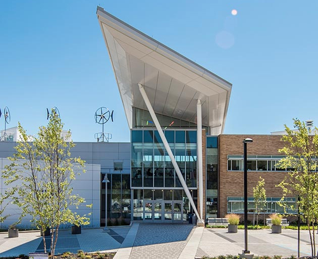

Germantown

```r
GT <- filter(mcData, Attending.Takoma.Park.SS =="No", Attending.Rockville == "No", Attending.Germantown == "Yes")
GT.Student.Type <- select(GT, Student.Type)
GT.studentTypeTable <- as.data.frame(table(GT.Student.Type))

GT.studentType <- arrange(GT.studentTypeTable, desc(Freq)) %>%
  mutate(Share.Enrollment = round((Freq / sum(Freq)),digits = 3))
GT.studentType
```

| GT.Student.Type | Freq | Share.Enrollment |
| --- | --- | --- |
| Continuing | 2526 | 0.688 |
| New | 772 | 0.210 |
| HS Student | 197 | 0.054 |
| Transfer no degree | 119 | 0.032 |
| Transfer with degree | 45 | 0.012 |
| Transfer | 8 | 0.002 |
| New/No HS | 5 | 0.001 |

```r
GT <- filter(mcData, Attending.Takoma.Park.SS =="No", Attending.Rockville == "No", Attending.Germantown == "Yes")
GT.Student.Gender <- select(GT, Gender)
GT.studentGenderTable <- as.data.frame(table(GT.Student.Gender))

GT.studentGender <- arrange(GT.studentGenderTable, desc(Freq)) %>%
  mutate(Share.Enrollment = round((Freq / sum(Freq)),digits = 3))
GT.studentGender
```

| GT.Student.Gender | Freq | Share.Enrollment |
| --- | --- | --- |
| Female | 1970 | 0.536 |
| Male | 1701 | 0.463 |
| Unknown | 1 | 0.000 |

```r
GT <- filter(mcData, Attending.Takoma.Park.SS =="No", Attending.Rockville == "No", Attending.Germantown == "Yes")
GT.Student.Race <- select(GT, Race)
GT.studentRaceTable <- as.data.frame(table(GT.Student.Race))

GT.studentRace <- arrange(GT.studentRaceTable, desc(Freq)) %>%
  mutate(Share.Enrollment = round((Freq / sum(Freq)),digits = 3))
GT.studentRace
```

| GT.Student.Race | Freq | Share.Enrollment |
| --- | --- | --- |
| White | 1702 | 0.464 |
| Black | 965 | 0.263 |
| Asian | 473 | 0.129 |
| Hispanic | 262 | 0.071 |
| Multi-Race | 162 | 0.044 |
| Native American | 55 | 0.015 |
| Pacific Islander | 47 | 0.013 |
| Unknown | 6 | 0.002 |

```r
GT <- filter(mcData, Attending.Takoma.Park.SS =="No", Attending.Rockville == "No", Attending.Germantown == "Yes")
GT.Student.Age.Group <- select(GT, Age.Group)
GT.studentAgeGroupTable <- as.data.frame(table(GT.Student.Age.Group))

GT.studentAgeGroup <- arrange(GT.studentAgeGroupTable, desc(Freq)) %>%
  mutate(Share.Enrollment = round((Freq / sum(Freq)),digits = 3))
GT.studentAgeGroup
```

| GT.Student.Age.Group | Freq | Share.Enrollment |
| --- | --- | --- |
| 20 or Younger | 1760 | 0.479 |
| 21 - 24 | 775 | 0.211 |
| 30 or Older | 737 | 0.201 |
| 25 - 29 | 400 | 0.109 |
| Unknown | 0 | 0.000 |

```r
GT <- filter(mcData, Attending.Takoma.Park.SS =="No", Attending.Rockville == "No", Attending.Germantown == "Yes")
GT.Student.City <- select(GT, City.in.MD)
GT.studentCityTable <- as.data.frame(table(GT.Student.City))

GT.studentCity <- arrange(GT.studentCityTable, desc(Freq)) %>%
  mutate(Share.Enrollment = round((Freq / sum(Freq)),digits = 3))
GT.studentCity
```

| GT.Student.City | Freq | Share.Enrollment |
| --- | --- | --- |
| Germantown | 1247 | 0.340 |
| Gaithersburg | 735 | 0.200 |
| Montgomery Village | 293 | 0.080 |
| Silver Spring | 243 | 0.066 |
| Clarksburg | 196 | 0.053 |
| Damascus | 179 | 0.049 |
| Rockville | 137 | 0.037 |
| Boyds | 114 | 0.031 |
| Olney | 59 | 0.016 |
| Poolesville | 59 | 0.016 |

[output cut: 232 more lines]

```r
GT <- filter(mcData, Attending.Takoma.Park.SS =="No", Attending.Rockville == "No", Attending.Germantown == "Yes")
GT.Student.Program <- select(GT, MC.Program.Description)
GT.studentProgramTable <- as.data.frame(table(GT.Student.Program))

GT.studentProgram <- arrange(GT.studentProgramTable, desc(Freq)) %>%
  mutate(Share.Enrollment = round((Freq / sum(Freq)),digits = 3))
GT.studentProgram
```

| GT.Student.Program | Freq | Share.Enrollment |
| --- | --- | --- |
| General Studies (AA - All Tracks) | 1249 | 0.340 |
| Health Sciences (Pre-Clinical Studies) | 425 | 0.116 |
| Business / International Business (AA) | 340 | 0.093 |
| Science (AS - All Tracks) | 190 | 0.052 |
| Credit (Undeclared / Undecided) | 168 | 0.046 |
| Education / Teacher Education (AA & AAT) | 168 | 0.046 |
| Engineering Science (AA & AS - All Tracks) | 166 | 0.045 |
| Computer Science & Technologies (AA - All Tracks) | 112 | 0.031 |
| Cybersecurity (AAS) | 111 | 0.030 |
| Criminal Justice (AA & AAS) | 91 | 0.025 |

[output cut: 86 more lines]

> Multiple Campus

> Reviewing the data file we see that some students were marked as “yes” for multiple campuses

[figure not shown]

That could make for some really long drives!

> Student body details (Takoma Park/Rockville)

```r
TP.RV <- filter(mcData, Attending.Takoma.Park.SS =="Yes", Attending.Rockville == "Yes", Attending.Germantown == "No")
TP.RV.Student.Type <- select(TP.RV, Student.Type)
TP.RV.studentTypeTable <- as.data.frame(table(TP.RV.Student.Type))

TP.RV.studentType <- arrange(TP.RV.studentTypeTable, desc(Freq)) %>%
  mutate(Share.Enrollment = round((Freq / sum(Freq)),digits = 3))
TP.RV.studentType
```

| TP.RV.Student.Type | Freq | Share.Enrollment |
| --- | --- | --- |
| Continuing | 1630 | 0.786 |
| New | 295 | 0.142 |
| Transfer no degree | 126 | 0.061 |
| Transfer with degree | 19 | 0.009 |
| Transfer | 3 | 0.001 |
| HS Student | 0 | 0.000 |
| New/No HS | 0 | 0.000 |

```r
TP.RV <- filter(mcData, Attending.Takoma.Park.SS =="Yes", Attending.Rockville == "Yes", Attending.Germantown == "No")
TP.RV.Student.Gender <- select(TP.RV, Gender)
TP.RV.studentGenderTable <- as.data.frame(table(TP.RV.Student.Gender))

TP.RV.studentGender <- arrange(TP.RV.studentGenderTable, desc(Freq)) %>%
  mutate(Share.Enrollment = round((Freq / sum(Freq)),digits = 3))
TP.RV.studentGender
```

| TP.RV.Student.Gender | Freq | Share.Enrollment |
| --- | --- | --- |
| Female | 1118 | 0.539 |
| Male | 955 | 0.461 |
| Unknown | 0 | 0.000 |

```r
TP.RV <- filter(mcData, Attending.Takoma.Park.SS =="Yes", Attending.Rockville == "Yes", Attending.Germantown == "No")
TP.RV.Student.Race <- select(TP.RV, Race)
TP.RV.studentRaceTable <- as.data.frame(table(TP.RV.Student.Race))

TP.RV.studentRace <- arrange(TP.RV.studentRaceTable, desc(Freq)) %>%
  mutate(Share.Enrollment = round((Freq / sum(Freq)),digits = 3))
TP.RV.studentRace
```

| TP.RV.Student.Race | Freq | Share.Enrollment |
| --- | --- | --- |
| Black | 965 | 0.466 |
| White | 614 | 0.296 |
| Asian | 210 | 0.101 |
| Hispanic | 170 | 0.082 |
| Multi-Race | 56 | 0.027 |
| Native American | 43 | 0.021 |
| Pacific Islander | 13 | 0.006 |
| Unknown | 2 | 0.001 |

```r
TP.RV <- filter(mcData, Attending.Takoma.Park.SS =="Yes", Attending.Rockville == "Yes", Attending.Germantown == "No")
TP.RV.Student.Age.Group <- select(TP.RV, Age.Group)
TP.RV.studentAgeGroupTable <- as.data.frame(table(TP.RV.Student.Age.Group))

TP.RV.studentAgeGroup <- arrange(TP.RV.studentAgeGroupTable, desc(Freq)) %>%
  mutate(Share.Enrollment = round((Freq / sum(Freq)),digits = 3))
TP.RV.studentAgeGroup
```

| TP.RV.Student.Age.Group | Freq | Share.Enrollment |
| --- | --- | --- |
| 20 or Younger | 730 | 0.352 |
| 21 - 24 | 547 | 0.264 |
| 30 or Older | 468 | 0.226 |
| 25 - 29 | 328 | 0.158 |
| Unknown | 0 | 0.000 |

```r
TP.RV <- filter(mcData, Attending.Takoma.Park.SS =="Yes", Attending.Rockville == "Yes", Attending.Germantown == "No")
TP.RV.Student.City <- select(TP.RV, City.in.MD)
TP.RV.studentCityTable <- as.data.frame(table(TP.RV.Student.City))

TP.RV.studentCity <- arrange(TP.RV.studentCityTable, desc(Freq)) %>%
  mutate(Share.Enrollment = round((Freq / sum(Freq)),digits = 3))
TP.RV.studentCity
```

| TP.RV.Student.City | Freq | Share.Enrollment |
| --- | --- | --- |
| Silver Spring | 1014 | 0.489 |
| Rockville | 167 | 0.081 |
| Gaithersburg | 106 | 0.051 |
| Takoma Park | 89 | 0.043 |
| Washington | 87 | 0.042 |
| Germantown | 61 | 0.029 |
| Bethesda | 58 | 0.028 |
| Hyattsville | 53 | 0.026 |
| Burtonsville | 41 | 0.020 |
| Olney | 34 | 0.016 |

[output cut: 232 more lines]

```r
TP.RV <- filter(mcData, Attending.Takoma.Park.SS =="Yes", Attending.Rockville == "Yes", Attending.Germantown == "No")
TP.RV.Student.Program <- select(TP.RV, MC.Program.Description)
TP.RV.studentProgramTable <- as.data.frame(table(TP.RV.Student.Program))

TP.RV.studentProgram <- arrange(TP.RV.studentProgramTable, desc(Freq)) %>%
  mutate(Share.Enrollment = round((Freq / sum(Freq)),digits = 3))
TP.RV.studentProgram
```

| TP.RV.Student.Program | Freq | Share.Enrollment |
| --- | --- | --- |
| General Studies (AA - All Tracks) | 570 | 0.275 |
| Health Sciences (Pre-Clinical Studies) | 320 | 0.154 |
| Business / International Business (AA) | 204 | 0.098 |
| Science (AS - All Tracks) | 124 | 0.060 |
| Engineering Science (AA & AS - All Tracks) | 122 | 0.059 |
| Arts & Sciences Transfer (AA - All Tracks) | 101 | 0.049 |
| Computer Science & Technologies (AA - All Tracks) | 78 | 0.038 |
| Education / Teacher Education (AA & AAT) | 70 | 0.034 |
| Credit (Undeclared / Undecided) | 60 | 0.029 |
| Criminal Justice (AA & AAS) | 48 | 0.023 |

[output cut: 86 more lines]

> Student body details (Rockville/Germantown)

```r
RV.GT <- filter(mcData, Attending.Takoma.Park.SS =="No", Attending.Rockville == "Yes", Attending.Germantown == "Yes")
RV.GT.Student.Type <- select(RV.GT, Student.Type)
RV.GT.studentTypeTable <- as.data.frame(table(RV.GT.Student.Type))

RV.GT.studentType <- arrange(RV.GT.studentTypeTable, desc(Freq)) %>%
  mutate(Share.Enrollment = round((Freq / sum(Freq)),digits = 3))
RV.GT.studentType
```

| RV.GT.Student.Type | Freq | Share.Enrollment |
| --- | --- | --- |
| Continuing | 2175 | 0.795 |
| New | 385 | 0.141 |
| Transfer no degree | 136 | 0.050 |
| HS Student | 17 | 0.006 |
| Transfer with degree | 17 | 0.006 |
| Transfer | 6 | 0.002 |
| New/No HS | 0 | 0.000 |

```r
RV.GT <- filter(mcData, Attending.Takoma.Park.SS =="No", Attending.Rockville == "Yes", Attending.Germantown == "Yes")
RV.GT.Student.Gender <- select(RV.GT, Gender)
RV.GT.studentGenderTable <- as.data.frame(table(RV.GT.Student.Gender))

RV.GT.studentGender <- arrange(RV.GT.studentGenderTable, desc(Freq)) %>%
  mutate(Share.Enrollment = round((Freq / sum(Freq)),digits = 3))
RV.GT.studentGender
```

| RV.GT.Student.Gender | Freq | Share.Enrollment |
| --- | --- | --- |
| Male | 1376 | 0.503 |
| Female | 1359 | 0.497 |
| Unknown | 1 | 0.000 |

```r
RV.GT <- filter(mcData, Attending.Takoma.Park.SS =="No", Attending.Rockville == "Yes", Attending.Germantown == "Yes")
RV.GT.Student.Race <- select(RV.GT, Race)
RV.GT.studentRaceTable <- as.data.frame(table(RV.GT.Student.Race))

RV.GT.studentRace <- arrange(RV.GT.studentRaceTable, desc(Freq)) %>%
  mutate(Share.Enrollment = round((Freq / sum(Freq)),digits = 3))
RV.GT.studentRace
```

| RV.GT.Student.Race | Freq | Share.Enrollment |
| --- | --- | --- |
| White | 1156 | 0.423 |
| Black | 723 | 0.264 |
| Asian | 463 | 0.169 |
| Hispanic | 202 | 0.074 |
| Multi-Race | 99 | 0.036 |
| Native American | 49 | 0.018 |
| Pacific Islander | 36 | 0.013 |
| Unknown | 8 | 0.003 |

```r
RV.GT <- filter(mcData, Attending.Takoma.Park.SS =="No", Attending.Rockville == "Yes", Attending.Germantown == "Yes")
RV.GT.Student.Age.Group <- select(RV.GT, Age.Group)
RV.GT.studentAgeGroupTable <- as.data.frame(table(RV.GT.Student.Age.Group))

RV.GT.studentAgeGroup <- arrange(RV.GT.studentAgeGroupTable, desc(Freq)) %>%
  mutate(Share.Enrollment = round((Freq / sum(Freq)),digits = 3))
RV.GT.studentAgeGroup
```

| RV.GT.Student.Age.Group | Freq | Share.Enrollment |
| --- | --- | --- |
| 20 or Younger | 1214 | 0.444 |
| 21 - 24 | 733 | 0.268 |
| 30 or Older | 443 | 0.162 |
| 25 - 29 | 346 | 0.126 |
| Unknown | 0 | 0.000 |

```r
RV.GT <- filter(mcData, Attending.Takoma.Park.SS =="No", Attending.Rockville == "Yes", Attending.Germantown == "Yes")
RV.GT.Student.City <- select(RV.GT, City.in.MD)
RV.GT.studentCityTable <- as.data.frame(table(RV.GT.Student.City))

RV.GT.studentCity <- arrange(RV.GT.studentCityTable, desc(Freq)) %>%
  mutate(Share.Enrollment = round((Freq / sum(Freq)),digits = 3))
RV.GT.studentCity
```

| RV.GT.Student.City | Freq | Share.Enrollment |
| --- | --- | --- |
| Gaithersburg | 587 | 0.215 |
| Germantown | 579 | 0.212 |
| Silver Spring | 370 | 0.135 |
| Rockville | 269 | 0.098 |
| Montgomery Village | 186 | 0.068 |
| Clarksburg | 98 | 0.036 |
| Damascus | 70 | 0.026 |
| Bethesda | 63 | 0.023 |
| Potomac | 61 | 0.022 |
| Olney | 60 | 0.022 |

[output cut: 232 more lines]

```r
RV.GT <- filter(mcData, Attending.Takoma.Park.SS =="No", Attending.Rockville == "Yes", Attending.Germantown == "Yes")
RV.GT.Student.Program <- select(RV.GT, MC.Program.Description)
RV.GT.studentProgramTable <- as.data.frame(table(RV.GT.Student.Program))

RV.GT.studentProgram <- arrange(RV.GT.studentProgramTable, desc(Freq)) %>%
  mutate(Share.Enrollment = round((Freq / sum(Freq)),digits = 3))
RV.GT.studentProgram
```

| RV.GT.Student.Program | Freq | Share.Enrollment |
| --- | --- | --- |
| General Studies (AA - All Tracks) | 842 | 0.308 |
| Business / International Business (AA) | 306 | 0.112 |
| Health Sciences (Pre-Clinical Studies) | 252 | 0.092 |
| Engineering Science (AA & AS - All Tracks) | 189 | 0.069 |
| Science (AS - All Tracks) | 178 | 0.065 |
| Computer Science & Technologies (AA - All Tracks) | 132 | 0.048 |
| Education / Teacher Education (AA & AAT) | 108 | 0.039 |
| Arts & Sciences Transfer (AA - All Tracks) | 106 | 0.039 |
| Cybersecurity (AAS) | 76 | 0.028 |
| Credit (Undeclared / Undecided) | 70 | 0.026 |

[output cut: 86 more lines]

> Student body details (Takoma Park/Germantown)

```r
TP.GT <- filter(mcData, Attending.Takoma.Park.SS =="Yes", Attending.Rockville == "No", Attending.Germantown == "Yes")
TP.GT.Student.Type <- select(TP.GT, Student.Type)
TP.GT.studentTypeTable <- as.data.frame(table(TP.GT.Student.Type))

TP.GT.studentType <- arrange(TP.GT.studentTypeTable, desc(Freq)) %>%
  mutate(Share.Enrollment = round((Freq / sum(Freq)),digits = 3))
TP.GT.studentType
```

| TP.GT.Student.Type | Freq | Share.Enrollment |
| --- | --- | --- |
| Continuing | 371 | 0.808 |
| New | 45 | 0.098 |
| Transfer no degree | 36 | 0.078 |
| Transfer with degree | 4 | 0.009 |
| HS Student | 3 | 0.007 |
| New/No HS | 0 | 0.000 |
| Transfer | 0 | 0.000 |

```r
TP.GT <- filter(mcData, Attending.Takoma.Park.SS =="Yes", Attending.Rockville == "No", Attending.Germantown == "Yes")
TP.GT.Student.Gender <- select(TP.GT, Gender)
TP.GT.studentGenderTable <- as.data.frame(table(TP.GT.Student.Gender))

TP.GT.studentGender <- arrange(TP.GT.studentGenderTable, desc(Freq)) %>%
  mutate(Share.Enrollment = round((Freq / sum(Freq)),digits = 3))
TP.GT.studentGender
```

| TP.GT.Student.Gender | Freq | Share.Enrollment |
| --- | --- | --- |
| Female | 287 | 0.625 |
| Male | 172 | 0.375 |
| Unknown | 0 | 0.000 |

```r
TP.GT <- filter(mcData, Attending.Takoma.Park.SS =="Yes", Attending.Rockville == "No", Attending.Germantown == "Yes")
TP.GT.Student.Race <- select(TP.GT, Race)
TP.GT.studentRaceTable <- as.data.frame(table(TP.GT.Student.Race))

TP.GT.studentRace <- arrange(TP.GT.studentRaceTable, desc(Freq)) %>%
  mutate(Share.Enrollment = round((Freq / sum(Freq)),digits = 3))
TP.GT.studentRace
```

| TP.GT.Student.Race | Freq | Share.Enrollment |
| --- | --- | --- |
| Black | 197 | 0.429 |
| White | 149 | 0.325 |
| Asian | 53 | 0.115 |
| Hispanic | 41 | 0.089 |
| Multi-Race | 11 | 0.024 |
| Native American | 4 | 0.009 |
| Pacific Islander | 3 | 0.007 |
| Unknown | 1 | 0.002 |

```r
TP.GT <- filter(mcData, Attending.Takoma.Park.SS =="Yes", Attending.Rockville == "No", Attending.Germantown == "Yes")
TP.GT.Student.Age.Group <- select(TP.GT, Age.Group)
TP.GT.studentAgeGroupTable <- as.data.frame(table(TP.GT.Student.Age.Group))

TP.GT.studentAgeGroup <- arrange(TP.GT.studentAgeGroupTable, desc(Freq)) %>%
  mutate(Share.Enrollment = round((Freq / sum(Freq)),digits = 3))
TP.GT.studentAgeGroup
```

| TP.GT.Student.Age.Group | Freq | Share.Enrollment |
| --- | --- | --- |
| 20 or Younger | 136 | 0.296 |
| 30 or Older | 113 | 0.246 |
| 25 - 29 | 106 | 0.231 |
| 21 - 24 | 104 | 0.227 |
| Unknown | 0 | 0.000 |

```r
TP.GT <- filter(mcData, Attending.Takoma.Park.SS =="Yes", Attending.Rockville == "No", Attending.Germantown == "Yes")
TP.GT.Student.City <- select(TP.GT, City.in.MD)
TP.GT.studentCityTable <- as.data.frame(table(TP.GT.Student.City))

TP.GT.studentCity <- arrange(TP.GT.studentCityTable, desc(Freq)) %>%
  mutate(Share.Enrollment = round((Freq / sum(Freq)),digits = 3))
TP.GT.studentCity
```

| TP.GT.Student.City | Freq | Share.Enrollment |
| --- | --- | --- |
| Silver Spring | 163 | 0.355 |
| Germantown | 61 | 0.133 |
| Gaithersburg | 48 | 0.105 |
| Washington | 21 | 0.046 |
| Montgomery Village | 15 | 0.033 |
| Rockville | 14 | 0.031 |
| Takoma Park | 14 | 0.031 |
| Bethesda | 11 | 0.024 |
| Derwood | 9 | 0.020 |
| Hyattsville | 8 | 0.017 |

[output cut: 232 more lines]

```r
TP.GT <- filter(mcData, Attending.Takoma.Park.SS =="Yes", Attending.Rockville == "No", Attending.Germantown == "Yes")
TP.GT.Student.Program <- select(TP.GT, MC.Program.Description)
TP.GT.studentProgramTable <- as.data.frame(table(TP.GT.Student.Program))

TP.GT.studentProgram <- arrange(TP.GT.studentProgramTable, desc(Freq)) %>%
  mutate(Share.Enrollment = round((Freq / sum(Freq)),digits = 3))
TP.GT.studentProgram
```

| TP.GT.Student.Program | Freq | Share.Enrollment |
| --- | --- | --- |
| General Studies (AA - All Tracks) | 119 | 0.259 |
| Health Sciences (Pre-Clinical Studies) | 82 | 0.179 |
| Business / International Business (AA) | 40 | 0.087 |
| Science (AS - All Tracks) | 30 | 0.065 |
| Education / Teacher Education (AA & AAT) | 22 | 0.048 |
| Engineering Science (AA & AS - All Tracks) | 21 | 0.046 |
| Credit (Undeclared / Undecided) | 16 | 0.035 |
| Paralegal Studies (AA & AAS) | 16 | 0.035 |
| Arts & Sciences Transfer (AA - All Tracks) | 14 | 0.031 |
| Computer Science & Technologies (AA - All Tracks) | 12 | 0.026 |

[output cut: 86 more lines]

```r
y = subset(GT.studentType)
```

```r
statusSummaryList <-list(GT.studentType[[1,"GT.Student.Type"]], RV.studentType[[1,"RV.Student.Type"]],
                         TP.SS.studentType[[1,"TP.SS.Student.Type"]], RV.GT.studentType[[1,"RV.GT.Student.Type"]],
                         TP.RV.studentType[[1,"TP.RV.Student.Type"]], TP.GT.studentType[[1,"TP.GT.Student.Type"]])
genderMaleSummaryList <-list(GT.studentGender[[1,"Share.Enrollment"]], RV.studentGender[[1,"Share.Enrollment"]],
                         TP.SS.studentGender[[1,"Share.Enrollment"]], RV.GT.studentGender[[1,"Share.Enrollment"]],
                         TP.RV.studentGender[[1,"Share.Enrollment"]], TP.GT.studentGender[[1,"Share.Enrollment"]])

#statusSummaryList
mcSummary <- data.frame("Campus" = c("Germantown","Rockville", "Takoma Park/Silver Spring", "Germantown/Rockville",
                                     "Rockville/TPSS", "Germantown/TPSS"),
                        "Most Common Status" = statusSummaryList,
                        "Share of Male Students" = genderMaleSummaryList,
                        "Share of Female Students" = "",
                        "Most Common Program" = "",
                        "Share Who Identify as Black" = "",
                        "Share who Identify as White" = "",
                        "Share who Identify as Hispanic" = "",
                        "Share who Identify as Asian" = "",
                        "Most common City of Residence" = "",
                        stringsAsFactors = FALSE)

mcSummary
```

| Campus | Most.Common.Status.structure.1L...Label...c..Continuing....HS.Student....New....New.No.HS... | Most.Common.Status.structure.1L...Label...c..Continuing....HS.Student....New....New.No.HS....1 | Most.Common.Status.structure.1L...Label...c..Continuing....HS.Student....New....New.No.HS....2 | Most.Common.Status.structure.1L...Label...c..Continuing....HS.Student....New....New.No.HS....3 | Most.Common.Status.structure.1L...Label...c..Continuing....HS.Student....New....New.No.HS....4 | Most.Common.Status.structure.1L...Label...c..Continuing....HS.Student....New....New.No.HS....5 | Share.of.Male.Students.0.536 | Share.of.Male.Students.0.506 | Share.of.Male.Students.0.593 | Share.of.Male.Students.0.503 | Share.of.Male.Students.0.539 | Share.of.Male.Students.0.625 | Share.of.Female.Students | Most.Common.Program | Share.Who.Identify.as.Black | Share.who.Identify.as.White | Share.who.Identify.as.Hispanic | Share.who.Identify.as.Asian | Most.common.City.of.Residence |
| --- | --- | --- | --- | --- | --- | --- | --- | --- | --- | --- | --- | --- | --- | --- | --- | --- | --- | --- | --- |
| Germantown | Continuing | Continuing | Continuing | Continuing | Continuing | Continuing | 0.536 | 0.506 | 0.593 | 0.503 | 0.539 | 0.625 |  |  |  |  |  |  |  |
| Rockville | Continuing | Continuing | Continuing | Continuing | Continuing | Continuing | 0.536 | 0.506 | 0.593 | 0.503 | 0.539 | 0.625 |  |  |  |  |  |  |  |
| Takoma Park/Silver Spring | Continuing | Continuing | Continuing | Continuing | Continuing | Continuing | 0.536 | 0.506 | 0.593 | 0.503 | 0.539 | 0.625 |  |  |  |  |  |  |  |
| Germantown/Rockville | Continuing | Continuing | Continuing | Continuing | Continuing | Continuing | 0.536 | 0.506 | 0.593 | 0.503 | 0.539 | 0.625 |  |  |  |  |  |  |  |
| Rockville/TPSS | Continuing | Continuing | Continuing | Continuing | Continuing | Continuing | 0.536 | 0.506 | 0.593 | 0.503 | 0.539 | 0.625 |  |  |  |  |  |  |  |
| Germantown/TPSS | Continuing | Continuing | Continuing | Continuing | Continuing | Continuing | 0.536 | 0.506 | 0.593 | 0.503 | 0.539 | 0.625 |  |  |  |  |  |  |  |

```r
mcSummary <- data.frame("Campus" = c("Germantown","Rockville", "Takoma Park/Silver Spring", "Germantown/Rockville",
                                     "Rockville/TPSS", "Germantown/TPSS"),
                        "Most Common Status" = list(GT.studentType[[1,"GT.Student.Type"]], RV.studentType[[1,"RV.Student.Type"]],
                         TP.SS.studentType[[1,"TP.SS.Student.Type"]], RV.GT.studentType[[1,"RV.GT.Student.Type"]],
                         TP.RV.studentType[[1,"TP.RV.Student.Type"]], TP.GT.studentType[[1,"TP.GT.Student.Type"]]),
                        "Share of Male Students" = genderMaleSummaryList,
                        "Share of Female Students" = "",
                        "Most Common Program" = "",
                        "Share Who Identify as Black" = "",
                        "Share who Identify as White" = "",
                        "Share who Identify as Hispanic" = "",
                        "Share who Identify as Asian" = "",
                        "Most common City of Residence" = "",
                        stringsAsFactors = FALSE)

mcSummary
```

| Campus | Most.Common.Status.structure.1L...Label...c..Continuing....HS.Student....New....New.No.HS... | Most.Common.Status.structure.1L...Label...c..Continuing....HS.Student....New....New.No.HS....1 | Most.Common.Status.structure.1L...Label...c..Continuing....HS.Student....New....New.No.HS....2 | Most.Common.Status.structure.1L...Label...c..Continuing....HS.Student....New....New.No.HS....3 | Most.Common.Status.structure.1L...Label...c..Continuing....HS.Student....New....New.No.HS....4 | Most.Common.Status.structure.1L...Label...c..Continuing....HS.Student....New....New.No.HS....5 | Share.of.Male.Students.0.536 | Share.of.Male.Students.0.506 | Share.of.Male.Students.0.593 | Share.of.Male.Students.0.503 | Share.of.Male.Students.0.539 | Share.of.Male.Students.0.625 | Share.of.Female.Students | Most.Common.Program | Share.Who.Identify.as.Black | Share.who.Identify.as.White | Share.who.Identify.as.Hispanic | Share.who.Identify.as.Asian | Most.common.City.of.Residence |
| --- | --- | --- | --- | --- | --- | --- | --- | --- | --- | --- | --- | --- | --- | --- | --- | --- | --- | --- | --- |
| Germantown | Continuing | Continuing | Continuing | Continuing | Continuing | Continuing | 0.536 | 0.506 | 0.593 | 0.503 | 0.539 | 0.625 |  |  |  |  |  |  |  |
| Rockville | Continuing | Continuing | Continuing | Continuing | Continuing | Continuing | 0.536 | 0.506 | 0.593 | 0.503 | 0.539 | 0.625 |  |  |  |  |  |  |  |
| Takoma Park/Silver Spring | Continuing | Continuing | Continuing | Continuing | Continuing | Continuing | 0.536 | 0.506 | 0.593 | 0.503 | 0.539 | 0.625 |  |  |  |  |  |  |  |
| Germantown/Rockville | Continuing | Continuing | Continuing | Continuing | Continuing | Continuing | 0.536 | 0.506 | 0.593 | 0.503 | 0.539 | 0.625 |  |  |  |  |  |  |  |
| Rockville/TPSS | Continuing | Continuing | Continuing | Continuing | Continuing | Continuing | 0.536 | 0.506 | 0.593 | 0.503 | 0.539 | 0.625 |  |  |  |  |  |  |  |
| Germantown/TPSS | Continuing | Continuing | Continuing | Continuing | Continuing | Continuing | 0.536 | 0.506 | 0.593 | 0.503 | 0.539 | 0.625 |  |  |  |  |  |  |  |